# SC2001 Project 1: Integration of Merge Sort & Insertion Sort

This notebook explains the implementation and reads **saved full-run results**. It does not generate large inputs or run benchmarks. Start with the small demo in the terminal if you want to see the algorithm operate.

The assignment asks for hybrid implementation, integer inputs from 1,000 to 10,000,000, three threshold/size studies, and an original-versus-hybrid comparison on 10 million integers. Presentation time is 8 minutes plus 2 minutes of Q&A. Requirements come from `sources/Project1.pdf` and `sources/info.pdf`.

## Algorithm and correctness

Use half-open ranges [lo,hi), split at lo+(hi-lo)//2, and stop when hi-lo <= S. Insertion establishes a sorted prefix; merge repeatedly emits the smallest remaining head. By induction, sorted children yield a sorted parent. Each step preserves the multiset. Taking the left value on <= and shifting only on > makes the sort stable. Empty/single-item ranges are already sorted.

```
hybrid(A, lo, hi, S):
    if hi-lo <= S: insertion(A, lo, hi); return
    mid = lo + floor((hi-lo)/2)
    hybrid(A, lo, mid, S)
    hybrid(A, mid, hi, S)
    merge(A, lo, mid, hi, shared_buffer)
```

Worked example, S=3: [5,2,4 | 1,3,6] becomes [2,4,5 | 1,3,6]. Insertion counts are 3+2; merging counts are 5; total 10. The original algorithm also makes 10 comparisons on this particular input. This illustrates mechanics, not a general speed claim.

Reusable code is in `algorithms.py`. Focused tests compare to `sorted` only on small cases, test all ternary arrays of lengths 0 through 6, cover the requested edge cases, and check stability and counted/uncounted equivalence. An AST test checks the merge and insertion loops differ only in accounting.

# Theory and counting conventions

## What counts

A **key comparison** compares two stored data values for ordering. Merge evaluates `values[left] <= values[right]` once while both halves have remaining values. Both true and false outcomes count. Once a half is exhausted, copying the remainder uses no key comparisons. Merging nonempty halves of lengths a and b takes between min(a,b) and a+b-1 key comparisons.

Insertion compares `values[previous] > key` whenever `previous >= lo`. A true comparison shifts the earlier value. A false comparison stops shifting and DOES count. If the index falls below lo, the key comparison is never evaluated and does NOT count. Index checks, recursion/threshold checks, moving values and validation are excluded. For [3,1,2], insertion's comparisons are 3>1 (true), 3>2 (true), 1>2 (false): exactly 3.

## Original merge sort

For n>1, split into a=floor(n/2) and b=ceil(n/2):

`T(n) = T(a) + T(b) + Theta(n)`, with `T(0), T(1) = Theta(1)`.

The linear merge work includes copying, so running time is Theta(n log n) in best, average and worst cases for n>=2. Comparisons also have Theta(n log n) growth for balanced splits. For powers of two the best comparison count is (n/2)log2(n). The worst count for any n>=1 is `n*ceil(log2(n)) - 2**ceil(log2(n)) + 1`. For n=4 this is 5, although already sorted and reverse-sorted inputs each need 4. Worst case is not synonymous with reverse order for merge sort.

The shared buffer has n slots, hence Theta(n) auxiliary storage. The recursion stack is O(log n). Input/base copies belong to the experiment's memory use and are distinct from the algorithm's auxiliary-space analysis.

## Insertion sort

On m>=1 already sorted or all-equal values: m-1 comparisons, Theta(m) time. On strictly decreasing values: m(m-1)/2 comparisons and shifts, Theta(m^2) time. On a uniformly random permutation of m distinct values, the expected number of inversions (and shifts) is m(m-1)/4. There are also terminating false comparisons. At insertion position i (zero based), one is absent precisely when the new item is a strict prefix minimum, probability 1/(i+1). Summing gives:

`E[C_insert(m)] = m(m-1)/4 + m - H_m`, where `H_m = sum(1/i, i=1..m)`.

The average time is Theta(m^2) under that random-permutation assumption. For IID uniform integers in [1,x], ties are possible and do not shift: expected inversions are `m(m-1)(x-1)/(4x)`. Thus the distinct model is an approximation to our data, not an exact expected count for all x. At x=1, all data are equal and insertion is linear. Insertion itself uses O(1) extra space.

## Hybrid merge levels and leaf work

Let B=min(S,n), for n>=1 and S>=1. Splits stop at lengths <=S, NOT after S levels. For n>S, there are about n/S leaves, each of size approximately S (between roughly S/2 and S), and about log2(n/S) merging levels. Each merge level touches O(n) values. Integer midpoint rounding changes actual leaves in steps.

For power-of-two n and S dividing n into power-of-two leaves:

- Number of leaves = n/S; merge levels = log2(n/S).
- Worst insertion-leaf comparisons = (n/S)*S(S-1)/2 = n(S-1)/2.
- Random-distinct insertion-leaf expectation = (n/S)*[S(S-1)/4 + S-H_S].
- Merge comparison upper bound = n log2(n/S) - n/S + 1.

Combining gives worst time `Theta(n*(1 + log2(n/B)) + n*B)`; for random distinct input, expected time has the same asymptotic order. A convenient big-O form is `O(n log(n/S) + nS)` for 1<=S<=n, with the constant/edge cases understood. Best time is `Theta(n*(1 + log2(n/B)))` because each insertion leaf is linear.

- Fixed S: Theta(n log n) expected/worst growth; S affects constant factors.
- S=1: same partitions, merges, output and key counts as original merge sort. Our hybrid still calls the empty/single-item insertion helper, so CPU need not match the baseline exactly; comparisons must match.
- Growing S: use the full expression. S=log n still gives Theta(n log n). S=n^alpha (0<alpha<=1) gives Theta(n^(1+alpha)) worst/average leaf work.
- S>=n: one insertion sort, no merges, average/worst Theta(n^2), best Theta(n). The current public hybrid API still allocates/provides an n-slot buffer, even though this extreme case does not use it, so its implemented auxiliary storage remains O(n). A dedicated insertion-only call uses O(1).

## Analytical curves used in the plots

`theory.py` recurses over actual rounded subproblem lengths. A merge of sorted random DISTINCT halves of sizes a,b has expected comparisons `a+b-a/(b+1)-b/(a+1)`: merging omits the final trailing run, whose expected length is a/(b+1)+b/(a+1). Combine this with the insertion expectation above. This is exact for uniform distinct permutations and serves as an approximation for our tied integer samples. The worst curve uses insertion m(m-1)/2 and merge a+b-1. No fitted constant or scaling is applied to either analytical count curve. The normalized c(i) plot divides measured C by n log2(n); it is a diagnostic ratio, not another measured comparison count.

For fixed n, increasing S removes merging levels in steps but increases insertion work. Different S values can yield exactly the same recursion tree and counts. The plots use actual leaf lengths to explain plateaus; no smooth optimum is assumed.

## Why comparisons and CPU time can disagree

Comparisons omit function calls, loop/index operations, pointer assignments, buffer copying and integer-counter updates. Fewer recursive calls can save CPU even if insertion increases comparisons. Python executes all measured loops; no built-in sort or compiled/JIT replacement performs the measured sorting. Counted runs increment Python integers; their CPU times are intentionally absent from the timed results. Both versions share structure, verified by tests.

Random seeds vary arrangement; equal keys affect early exhaustion and insertion shifts. OS scheduling, clock quantization and machine load can affect repeated timings. CPU seconds measure this process's CPU use, whereas wall seconds include waiting. Three seeds support descriptive median/min/max comparisons, not a strong claim about every workload or hardware platform. Cache/thermal explanations are possible hypotheses, not measured causal findings here.

In this run, recorded CPU totals commonly fell on 0.015625-second increments. The clock metadata reports a nominal resolution of 1e-7 seconds via GetProcessTimes, which does not guarantee that a tiny experiment receives CPU charges at that granularity. Small-case batching addresses the observed quantization. It does not remove all scheduling or workload noise. Smoke batches are deliberately short and unsuitable for drawing performance conclusions.

## Reproducible experiment protocol

Uniform `randint(1,x)` with x=1,000,000; recorded seeds; independent seed per repeat. Candidates use identical unsorted data. Counted and uncounted runs are separate. `time.process_time()` records only sorting CPU; wall time is a separate column. Input copies, RNG, buffer allocation, warmup, checks, plotting and I/O are excluded. Small sorts are batched from independent pre-timer copies; per-sort times and raw batch totals are recorded. GC is collected before timing, disabled during sorting, then restored. One small deterministic warmup precedes each case; order is shuffled with a recorded seed; all comparative sorting is sequential.

Three measured seeds per full case; plots show median and observed min-max where visible. These bars are not confidence intervals. CPU is the primary selection criterion, and counts are reported independently. The configuration and source hashes prevent incompatible resume; the CSV saves each verified completed case.

Large output checks: exact length, nondecreasing order, sum, squared sum, XOR, and exact frequency histogram for this bounded range. SHA-256 identifies paired input order and cross-checks counted/uncounted outputs. Checksums alone can collide; the histogram establishes exact multiset preservation without a reference sort.

```python
from pathlib import Path
import json
import pandas as pd
from IPython.display import display, Image

ROOT = Path.cwd()
if not (ROOT / 'results/full/raw.csv').exists():
    ROOT = ROOT / 'project1'
raw = pd.read_csv(ROOT / 'results/full/raw.csv')
metadata = json.loads((ROOT / 'results/full/metadata.json').read_text())
findings = json.loads((ROOT / 'plots/full/findings.json').read_text())
display(pd.Series(metadata['config'], name='Configuration'))
display(pd.Series(metadata['environment'], name='Environment'))
display(raw.head(8))
```

```
name                                                                  full
x                                                                  1000000
repeats                                                                  3
modes                                                     [timed, counted]
warmup_n                                                              4096
timed_batch_items                                                   500000
fixed_s                                                                 16
sizes                    [1000, 10000, 100000, 300000, 1000000, 3000000...
fixed_n                                                             100000
tuning_sizes                                         [1000, 10000, 100000]
thresholds                               [1, 4, 8, 12, 16, 24, 32, 48, 64]
shortlist_count                                                          3
confirmation_n                                                     1000000
final_n                                                           10000000
seed_bases               {'scale': 200100, 'tune': 300100, 'confirm': 4...
primary_criterion        lowest median uncounted CPU time on confirmati...
shortlist_rule           three lowest geometric means of median CPU rat...
order_seed                                                           73129
exact_histogram_max_x                                              1000000
Name: Configuration, dtype: object
```

```
python_version        3.13.6 (tags/v3.13.6:4e66535, Aug  6 2025, 14:...
executable            C:\Users\daboi\Documents\ChatGPT\SC2001\projec...
platform                                      Windows-11-10.0.26200-SP0
machine                                                           AMD64
hardware              {'logical_cpus': 14, 'physical_cores': 12, 'to...
process_time_clock    {'implementation': 'GetProcessTimes()', 'monot...
created_utc                            2026-09-13T10:55:12.604722+00:00
environment_id                                         0c66ee43f1117e7a
Name: Environment, dtype: object
```

|  | case_id | config_hash | environment_id | experiment | stage | algorithm | n | S | x | seed | ... | integrity_ok | input_sum | input_sum_squares | input_xor | dataset_sha256 | output_sha256 | rss_bytes_after | python_version | platform | completed_utc |
| --- | --- | --- | --- | --- | --- | --- | --- | --- | --- | --- | --- | --- | --- | --- | --- | --- | --- | --- | --- | --- | --- |
| 0 | tune:1000:0:hybrid:8:counted | 0cfc5c7c0a5005d27a3bb518d776b983a8427406ffd6c3... | 0c66ee43f1117e7a | c(iii) | tune | hybrid | 1000 | 8 | 1000000 | 310100 | ... | True | 500133472 | 328426401492916 | 533676 | 998f1635234f45492a696100253f18aea194252dd7d5cf... | 449e9d486a5120e818e99b17d86a5528a6d73dfee19b63... | 45223936 | 3.13.6 | Windows-11-10.0.26200-SP0 | 2026-09-13T10:55:12.621658+00:00 |
| 1 | tune:1000:0:hybrid:4:counted | 0cfc5c7c0a5005d27a3bb518d776b983a8427406ffd6c3... | 0c66ee43f1117e7a | c(iii) | tune | hybrid | 1000 | 4 | 1000000 | 310100 | ... | True | 500133472 | 328426401492916 | 533676 | 998f1635234f45492a696100253f18aea194252dd7d5cf... | 449e9d486a5120e818e99b17d86a5528a6d73dfee19b63... | 45305856 | 3.13.6 | Windows-11-10.0.26200-SP0 | 2026-09-13T10:55:12.641475+00:00 |
| 2 | tune:1000:0:hybrid:1:timed | 0cfc5c7c0a5005d27a3bb518d776b983a8427406ffd6c3... | 0c66ee43f1117e7a | c(iii) | tune | hybrid | 1000 | 1 | 1000000 | 310100 | ... | True | 500133472 | 328426401492916 | 533676 | 998f1635234f45492a696100253f18aea194252dd7d5cf... | 449e9d486a5120e818e99b17d86a5528a6d73dfee19b63... | 45703168 | 3.13.6 | Windows-11-10.0.26200-SP0 | 2026-09-13T10:55:13.272297+00:00 |
| 3 | tune:1000:0:hybrid:1:counted | 0cfc5c7c0a5005d27a3bb518d776b983a8427406ffd6c3... | 0c66ee43f1117e7a | c(iii) | tune | hybrid | 1000 | 1 | 1000000 | 310100 | ... | True | 500133472 | 328426401492916 | 533676 | 998f1635234f45492a696100253f18aea194252dd7d5cf... | 449e9d486a5120e818e99b17d86a5528a6d73dfee19b63... | 45727744 | 3.13.6 | Windows-11-10.0.26200-SP0 | 2026-09-13T10:55:13.290278+00:00 |
| 4 | tune:1000:0:hybrid:32:timed | 0cfc5c7c0a5005d27a3bb518d776b983a8427406ffd6c3... | 0c66ee43f1117e7a | c(iii) | tune | hybrid | 1000 | 32 | 1000000 | 310100 | ... | True | 500133472 | 328426401492916 | 533676 | 998f1635234f45492a696100253f18aea194252dd7d5cf... | 449e9d486a5120e818e99b17d86a5528a6d73dfee19b63... | 45580288 | 3.13.6 | Windows-11-10.0.26200-SP0 | 2026-09-13T10:55:13.781217+00:00 |
| 5 | tune:1000:0:hybrid:8:timed | 0cfc5c7c0a5005d27a3bb518d776b983a8427406ffd6c3... | 0c66ee43f1117e7a | c(iii) | tune | hybrid | 1000 | 8 | 1000000 | 310100 | ... | True | 500133472 | 328426401492916 | 533676 | 998f1635234f45492a696100253f18aea194252dd7d5cf... | 449e9d486a5120e818e99b17d86a5528a6d73dfee19b63... | 45563904 | 3.13.6 | Windows-11-10.0.26200-SP0 | 2026-09-13T10:55:14.431120+00:00 |
| 6 | tune:1000:0:hybrid:24:timed | 0cfc5c7c0a5005d27a3bb518d776b983a8427406ffd6c3... | 0c66ee43f1117e7a | c(iii) | tune | hybrid | 1000 | 24 | 1000000 | 310100 | ... | True | 500133472 | 328426401492916 | 533676 | 998f1635234f45492a696100253f18aea194252dd7d5cf... | 449e9d486a5120e818e99b17d86a5528a6d73dfee19b63... | 45690880 | 3.13.6 | Windows-11-10.0.26200-SP0 | 2026-09-13T10:55:15.384724+00:00 |
| 7 | tune:1000:0:hybrid:12:counted | 0cfc5c7c0a5005d27a3bb518d776b983a8427406ffd6c3... | 0c66ee43f1117e7a | c(iii) | tune | hybrid | 1000 | 12 | 1000000 | 310100 | ... | True | 500133472 | 328426401492916 | 533676 | 998f1635234f45492a696100253f18aea194252dd7d5cf... | 449e9d486a5120e818e99b17d86a5528a6d73dfee19b63... | 45797376 | 3.13.6 | Windows-11-10.0.26200-SP0 | 2026-09-13T10:55:15.414059+00:00 |

8 rows × 32 columns

## (c)(i): fix S=16 and vary n

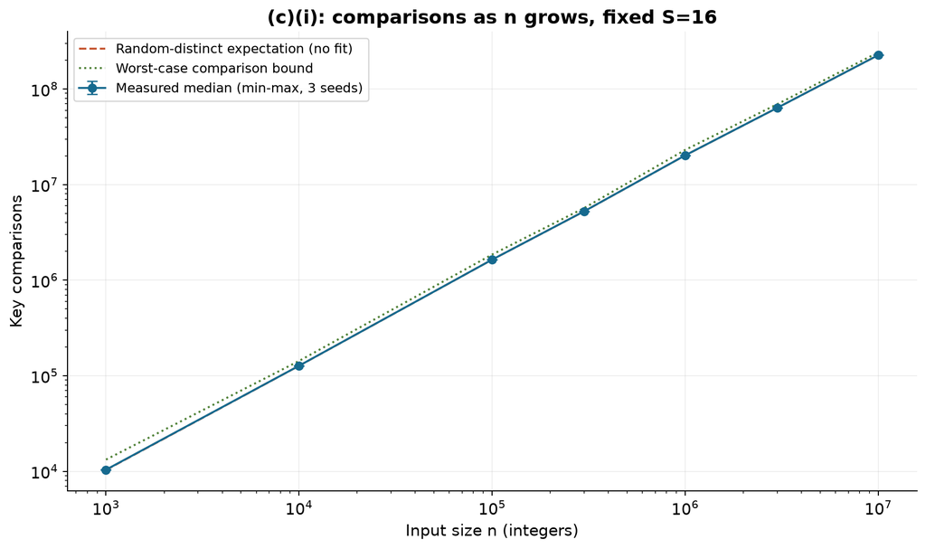

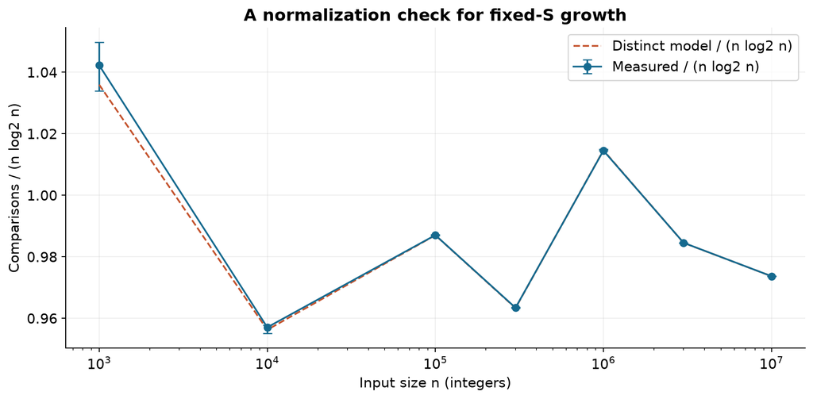

```python
display(Image(filename=str(ROOT / 'plots/full/c1_comparisons_vs_n.png')))
display(Image(filename=str(ROOT / 'plots/full/c1_normalized.png')))
```

The analytical curves have no fitted scale factor. The random-distinct curve approximates these samples with ties. The worst curve is a bound, not a prediction for random inputs. Normalization by n log2(n) tests consistency with fixed-S growth.

## (c)(ii): fix n=100,000 and vary S

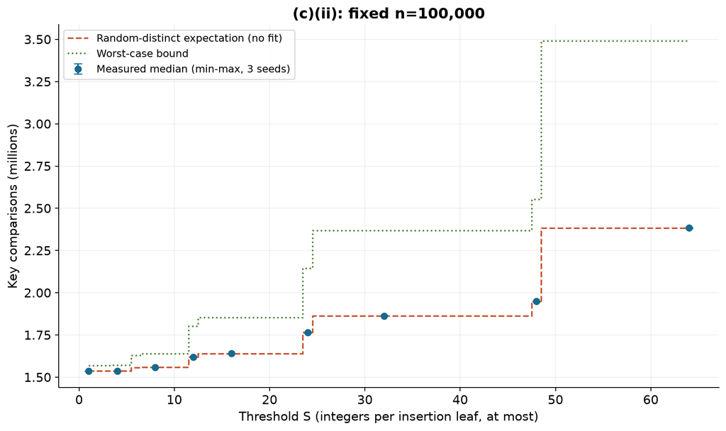

```
1                            {'1': 100000}
4                  {'3': 31072, '4': 1696}
8                  {'6': 14688, '7': 1696}
12      {'12': 6496, '6': 1696, '7': 1696}
16                {'12': 6496, '13': 1696}
24    {'24': 2400, '12': 1696, '13': 1696}
32                {'24': 2400, '25': 1696}
48     {'48': 352, '24': 1696, '25': 1696}
64                 {'48': 352, '49': 1696}
Name: Actual leaf sizes and counts, dtype: object
```

```python
display(Image(filename=str(ROOT / 'plots/full/c2_comparisons_vs_s.png')))
display(pd.Series(findings['actual_leaves_at_fixed_n'], name='Actual leaf sizes and counts'))
```

## (c)(iii): compare thresholds across input sizes

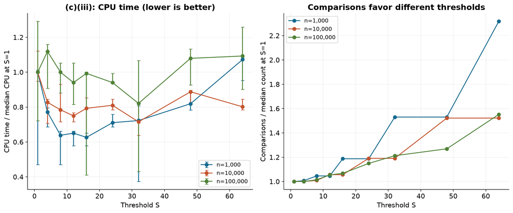

|  | n | cpu_best_s | cpu_median_seconds | comparison_best_s | comparison_median |
| --- | --- | --- | --- | --- | --- |
| 0 | 1000 | 16 | 0.001625 | 1 | 8706 |
| 1 | 10000 | 32 | 0.025937 | 1 | 120499 |
| 2 | 100000 | 32 | 0.387500 | 1 | 1536373 |

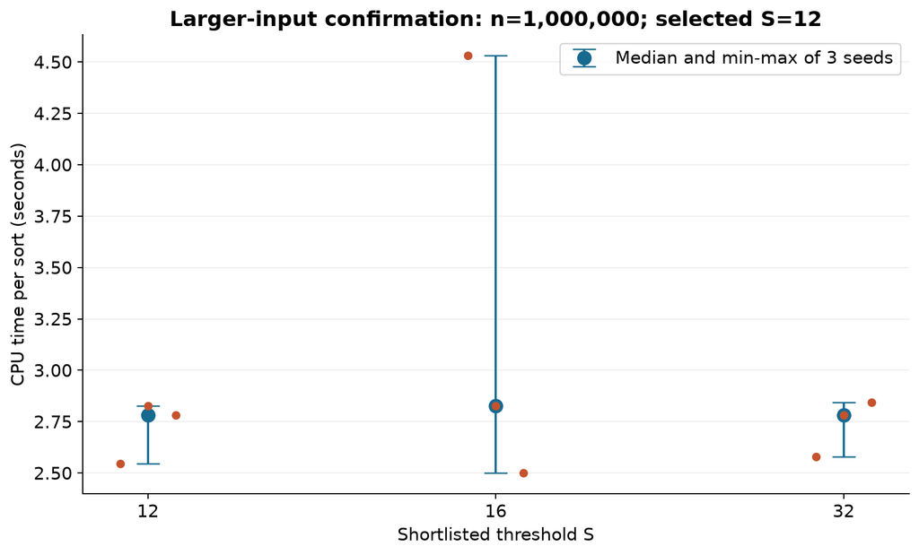

|  | S | median | min | max | std | count |
| --- | --- | --- | --- | --- | --- | --- |
| 0 | 12 | 2.781250 | 2.546875 | 2.828125 | 0.150682 | 3 |
| 1 | 16 | 2.828125 | 2.500000 | 4.531250 | 1.090434 | 3 |
| 2 | 32 | 2.781250 | 2.578125 | 2.843750 | 0.138878 | 3 |

```python
display(Image(filename=str(ROOT / 'plots/full/c3_threshold_tuning.png')))
display(pd.DataFrame(findings['tuning']))
display(Image(filename=str(ROOT / 'plots/full/c3_confirmation.png')))
display(pd.DataFrame(findings['confirmation']))
```

The CPU chart normalizes each size by its S=1 median; lower is faster. That normalization compares curve shapes without allowing the largest n to dominate. Shortlisting uses the geometric mean of these ratios. The larger confirmation set then selects its lowest median CPU, ties choosing smaller S. This finite search does not establish a universal optimum. Repeated values and split rounding create plateaus. Show uncertainty rather than claiming that every small difference matters.

## (d): original versus hybrid on 10,000,000 integers

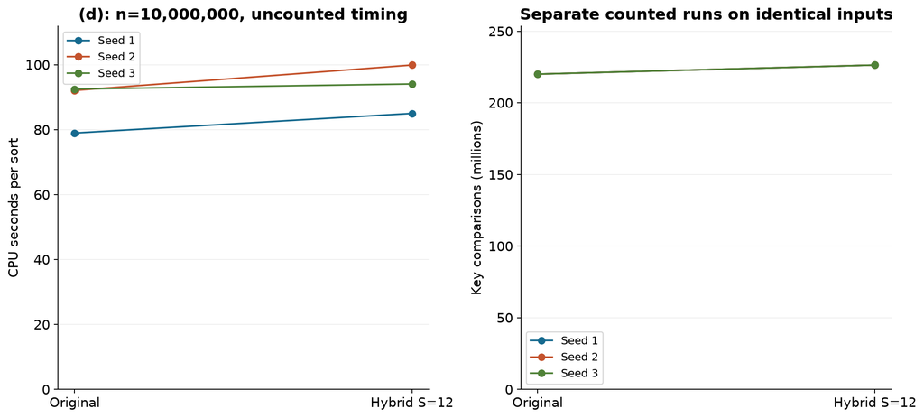

|  | repeat | hybrid | original | speedup |
| --- | --- | --- | --- | --- |
| 0 | 0 | 85.000000 | 78.968750 | 0.929044 |
| 1 | 1 | 99.906250 | 92.093750 | 0.921802 |
| 2 | 2 | 94.078125 | 92.515625 | 0.983391 |

|  | repeat | hybrid | original |
| --- | --- | --- | --- |
| 0 | 0 | 226418149.0 | 220095927.0 |
| 1 | 1 | 226424963.0 | 220099689.0 |
| 2 | 2 | 226417959.0 | 220101452.0 |

```python
display(Image(filename=str(ROOT / 'plots/full/d_final_comparison.png')))
display(pd.read_csv(ROOT / 'plots/full/final_paired_cpu.csv'))
display(pd.read_csv(ROOT / 'plots/full/final_paired_comparisons.csv'))
```

# Measured findings: full

All 234 planned measurement rows completed; 3 measured repeats per case. Counts and times come from separate runs. Smoke data are not assignment evidence.

## Threshold selection

| Input size n | Lowest median CPU S | Fewest median comparisons S |
| --- | --- | --- |
| 1,000 | 16 | 1 |
| 10,000 | 32 | 1 |
| 100,000 | 32 | 1 |

CPU ties in the displayed table use the smaller S. The saved shortlist applies the predeclared geometric-ratio rule across these sizes. At n=1,000,000, the lowest confirmation median selected **S=12**, best among the shortlisted tested values. Check the min-max intervals in `c3_confirmation.png`: three seeds do not establish a universal optimum or statistical significance.

## Final n=10,000,000 comparison

| Metric | Original | Hybrid S=12 |
| --- | --- | --- |
| Median CPU seconds | 92.093750 | 94.078125 |
| CPU min-max seconds | 78.968750-92.515625 | 85.000000-99.906250 |
| Median key comparisons | 220,099,689 | 226,418,149 |

Speedup per paired seed = original CPU seconds / hybrid CPU seconds. Median paired speedup = **0.929x**, range 0.922-0.983x. A value above 1 means the hybrid is faster. The ratio of the two medians is 0.979x; it is a different statistic. Hybrid median comparisons changed by +2.87% relative to original.

Across the three paired seeds, the hybrid was faster in **0**, slower in **3**, and tied in **0**. These observations include every measured regression; no repeat was discarded or replaced after seeing its result.

Raw per-repeat counts and times are in `final_paired_comparisons.csv` and `final_paired_cpu.csv`; the original raw observations remain in the results folder.

## Connection to theory

At fixed S=16, the comparison plot and C/(n log2 n) normalization are consistent with the derived Theta(n log n) fixed-threshold growth. The maximum absolute relative difference from the random-distinct expectation across the scale medians is 0.608%. That analytical curve is unscaled and is only approximate for repeated integers. Agreement over seven measured sizes is evidence of consistency, not a proof of asymptotic complexity; the recurrence supplies the proof.

For fixed n, increasing S creates stepwise changes in leaf sizes. Insertion work eventually increases faster than the saved merge comparisons. The CPU chart measures extra costs absent from the comparison count: recursion, loop/index operations, pointer assignments and copying. Separate instrumentation avoids count increments distorting the timed comparison.

## Scope and limitations

One CPython interpreter and one Windows laptop, IID uniform integers with x=1,000,000, three distinct seeds per case, and a finite threshold grid. Repeats mix input variation and timing variation; they are not independent hardware replications. Small-case batching repeats each seed's input, not additional independent datasets. Timers exclude input generation/reset, merge-buffer allocation, validation and I/O. The same machine was also used for lightweight document preparation; background OS/browser activity was not controlled. No cache or thermal profiling was done. Min-max bars are observed ranges, not confidence intervals. The largest recorded post-validation RSS was 583.1 MiB; this is a sampled process footprint, not a measured allocation peak. Exact frequency histograms plus sorted order prove the bounded-integer multiset was preserved. Fingerprints alone would not give that guarantee.

## Sources and requirement distinctions

# Requirements and source decisions

Read in full: `sources/Project1.pdf` (1 page) and `sources/info.pdf` (2 pages). These are copies of the user's files in `C:/Users/daboi/Downloads`. Their text and every page were inspected; no attachment was missing.

## Assignment requirements (the PDFs are the authority)

- (a) Switch from merge sort to insertion sort when the current range has at most S items.
- (b) Random integer arrays from n=1,000 through n=10,000,000, values in [1,x].
- (c)(i) Fixed S: key comparisons against n and theory.
- (c)(ii) Fixed n: key comparisons against S and theory.
- (c)(iii) Investigate a suitable S across different n.
- (d) Original lecture merge sort versus the hybrid on 10 million integers: key comparisons and CPU time, using a tuned S.
- Presentation: 10 minutes total, including 2 minutes of Q&A; every member understands all parts.
- Grading: correctness/implementation 40%, theoretical/empirical analysis 40%, presentation/clarity 20%.
- Teams of 3-4 are assigned by the lab TA. Suggested work allocation here does not form a new team.
- No submission is required for Projects 1 and 2. The repository and slides serve collaboration and demonstration.
- `info.pdf` also addresses attendance, absence with MC/LOA, participation and completion before the lab. Those are course instructions to students; no messages, invitations or submissions are sent by this project.

## Additional user requirements

Python only for algorithms and experiments; explicit counted/uncounted implementations; focused tests; reproducible seeds/configurations; at least three measured repeats where practical; CPU-time primary threshold selection; sequential fair timing; validation, resume, notebook, plots, documentation, presentation and learning materials. These details are requested by the user and are not claimed to appear in the PDFs.

## Design choices

- CPython 3.13, integer lists, one reusable list buffer; range [lo,hi).
- x=1,000,000, uniform `random.Random(seed).randint(1,x)`.
- Seven input sizes, exploratory fixed S=16 (not an optimality assumption).
- Nine tuning thresholds; three repeats at three sizes; confirm the three strongest CPU candidates at n=1,000,000. Use new seeds for the final n=10,000,000 comparison.
- Median CPU time is primary. The shortlist uses a geometric mean of per-size CPU ratios relative to S=1, weighting sizes equally. Confirmation chooses its lowest median, ties resolved by smaller S. No claim of global optimality.
- Timed small inputs use batches to reduce CPU clock quantization. Data resetting and buffer allocation stay outside timing. All full-run cases retain three repeats.
- Exact histograms validate these bounded integers; no giant reference sort needed.

## Lecture implementation that was actually available

`C:/Users/daboi/Downloads/01_Sorting.pdf`: pages 12, 14 and 15 were read and the algorithm pages visually checked. Page 12 specifies top-down recursion, floor midpoint and half-open ranges. Page 14 merges by iterating right-hand values and comparing the current left item using <=, taking left ties first. Its line 7 says B[j], interpreted as B_r[j] from context.

Our two-pointer merge makes the same sequence of data-order decisions: a true <= takes left, a false <= takes right, and the exhausted side produces no more key comparisons. For memory efficiency, our merge writes into a single shared buffer then copies back by index, instead of allocating B_l and B_r at every merge. Both baseline and hybrid share that exact merge routine. This is an explicitly documented storage/control-flow adaptation of the available lecture algorithm; the timing is of this Python implementation, not a literal execution of the slides. Existing course examples in `../code/python/sorting` are preserved.

A copy of the available lecture is included as `sources/01_Sorting.pdf` so team members can inspect the cited pages without depending on the original Downloads path.

## Source fingerprints

| File | SHA-256 |
| --- | --- |
| Project 1.pdf | `1a9b296c79ca2c2d0fcef643b1cbed78d3e394976c0b1348bb03c1580f796f3d` |
| info.pdf | `ae96f8bea5292c96a7b2f2eff1a346dcecfb83ea4f80775873c01f1c193949d2` |
| 01_Sorting.pdf | `cf5875f86a551fdcb7007091ad0faa0061cbe9937bd99f2fe58090b700cfa42f` |

The mathematical derivations in this project are provided directly. External technical references checked for API semantics (not assignment authority):

- [Python time documentation](https://docs.python.org/3/library/time.html#time.process_time): process CPU time excludes sleep, and perf_counter records elapsed wall time.
- [Python random documentation](https://docs.python.org/3/library/random.html#random.randint): randint(a,b) includes both endpoints.

The full interpreter version is recorded with the experiment. Live documentation may describe a newer Python release, so actual runtime metadata remains authoritative for the interpreter used to obtain these results.